# Practice lab 4 assignment

Andria Grace

2023-10-10

#1) What’s the probability of #a. rolling a 6 on a die

```r
p<-1/6
p
```

```
## [1] 0.1666667
```

#b. rolling three consecutive times a 6

```r
p<-1/6*1/6*1/6
p
```

```
## [1] 0.00462963
```

#c. rolling a 6, a 1 and a 6 again

```r
p<-1/6*1/6*1/6
p
```

```
## [1] 0.00462963
```

#2) Define categories of random variables and give at least 2 examples for each group. #a. Continuous

```r
## When a random variable takes continuous variable(Takes infinite values) is called continuous random variables.
##example: Time, Temperature
```

#b. Categorical

```r
##It contains a finite number of categories or a group. eg: Gender, Blood Type
```

#c. Discrete

```r
##  When a random variable takes specific or distinct variables within the interval is called discrete random variable.
##example:Number of Cars, rolling a die
```

#3) Normal distribution #a. Load the CDC dataset #Read data

```r
source("http://www.openintro.org/stat/data/cdc.R")
View(cdc)
#Functions
SD_pop<-function(x,n){sqrt(sum( (x - mean(x) )^2)/(n))}
```

#b. Calculate all index points for the empirical rule

```r
#calculate BMI
cdc$weight_kg<-cdc$weight/2.2
cdc$height_cm<-cdc$height * 2.5
cdc$height_m <-cdc$height_cm / 100
cdc$BMI <- cdc$weight_kg / cdc$height_m^2
df<-cdc
mean(df$BMI)
```

```
## [1] 27.21523
```

```r
SD_pop((df$BMI),length(df$BMI))
```

```
## [1] 5.398137
```

```r
c(round(mean(df$BMI)-1*SD_pop(df$BMI,length(df$BMI)),2), "to", mean(df$BMI)+1*SD_pop(df$BMI,length(df$BMI))) #68%
```

```
## [1] "21.82"            "to"               "32.6133709048639"
```

```r
c(mean(df$BMI)-2*SD_pop(df$BMI,length(df$BMI)), "to", mean(df$BMI)+2*SD_pop(df$BMI,length(df$BMI))) #95%
```

```
## [1] "16.4189591261852" "to"               "38.0115081644235"
```

```r
c(mean(df$BMI)-3*SD_pop(df$BMI,length(df$BMI)), "to", mean(df$BMI)+3*SD_pop(df$BMI,length(df$BMI))) #99.7%
```

```
## [1] "11.0208218666257" "to"               "43.4096454239831"
```

#c. Plot the normal distribution for BMI as a histogram in R

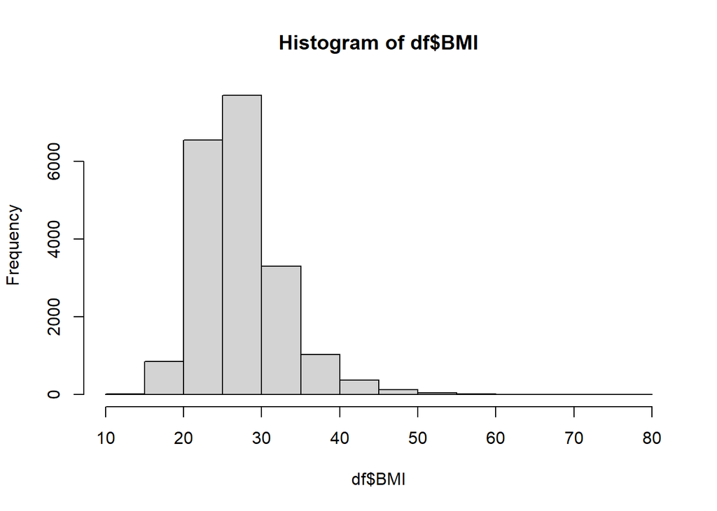

```r
hist(df$BMI)
```

#d. Indicate +/-1, 2 and 3 standard deviations in the histogram

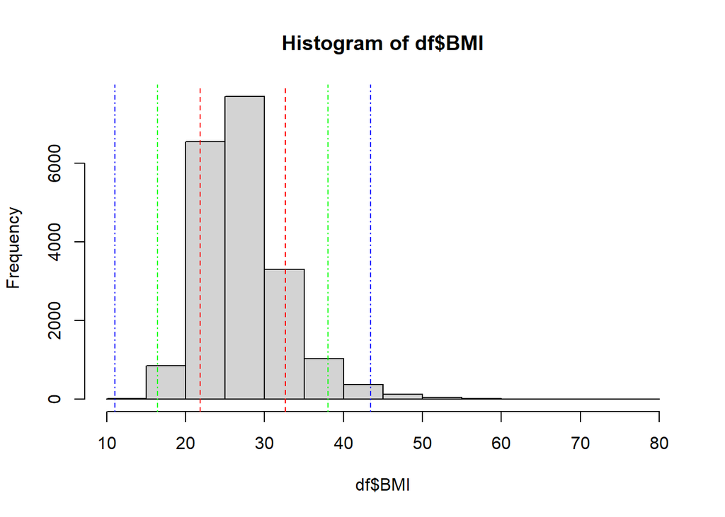

```r
hist(df$BMI)
abline(v=mean(df$BMI)-1*SD_pop(df$BMI,length(df$BMI)),col="red",lty=2)
abline(v=mean(df$BMI)-2*SD_pop(df$BMI,length(df$BMI)),col="green",lty=4)
abline(v=mean(df$BMI)-3*SD_pop(df$BMI,length(df$BMI)),col="blue",lty=4)
abline(v=mean(df$BMI)+1*SD_pop(df$BMI,length(df$BMI)),col="red",lty=2)
abline(v=mean(df$BMI)+2*SD_pop(df$BMI,length(df$BMI)),col="green",lty=4)
abline(v=mean(df$BMI)+3*SD_pop(df$BMI,length(df$BMI)),col="blue",lty=4)
```

#e. Calculate the above stated values, the z-scores and the probabilities

```r
z_scores=(df$BMI-mean(df$BMI))/SD_pop((df$BMI),length(df$BMI))
quantile(z_scores,probs = c(68,95,99.7)/100)
```

```
##       68%       95%     99.7%
## 0.2609161 1.8473680 4.3144173
```

#probabilities

```r
pnorm(mean(df$BMI)+1*SD_pop(df$BMI,length(df$BMI)),mean=mean(df$BMI),sd=SD_pop(df$BMI,length(df$BMI)), lower.tail = TRUE)-pnorm(mean(df$BMI)-1*SD_pop(df$BMI,length(df$BMI)),mean=mean(df$BMI),sd=SD_pop(df$BMI,length(df$BMI)), lower.tail = TRUE)
```

```
## [1] 0.6826895
```

```r
pnorm(mean(df$BMI)+2*SD_pop(df$BMI,length(df$BMI)),mean=mean(df$BMI),sd=SD_pop(df$BMI,length(df$BMI)), lower.tail = TRUE)-pnorm(mean(df$BMI)-2*SD_pop(df$BMI,length(df$BMI)),mean=mean(df$BMI),sd=SD_pop(df$BMI,length(df$BMI)), lower.tail = TRUE)
```

```
## [1] 0.9544997
```

```r
pnorm(mean(df$BMI)+3*SD_pop(df$BMI,length(df$BMI)),mean=mean(df$BMI),sd=SD_pop(df$BMI,length(df$BMI)), lower.tail = TRUE)-pnorm(mean(df$BMI)-3*SD_pop(df$BMI,length(df$BMI)),mean=mean(df$BMI),sd=SD_pop(df$BMI,length(df$BMI)), lower.tail = TRUE)
```

```
## [1] 0.9973002
```

#f. Create a standard normal distribution and plot the z-scores as a histogram

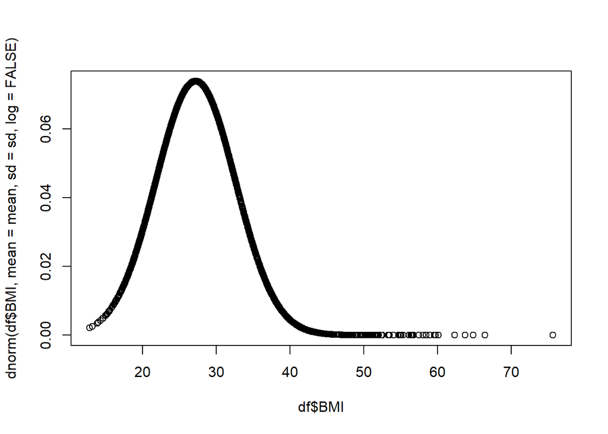

```r
#generate a simulated normal distribution curve
mean<-mean(df$BMI);sd=SD_pop(df$BMI,length(df$BMI))
x <- seq(-10, 10, by=0.1)
plot(df$BMI,dnorm(df$BMI, mean = mean, sd = sd, log = FALSE))
```

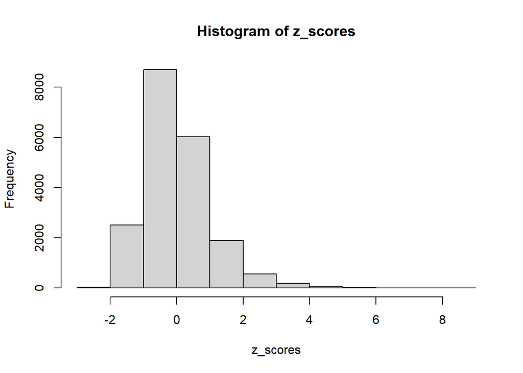

```r
hist(z_scores)
```

#Calculate probability for the following examples #i. 4 individuals enter a clinic, what’s the p that exactly 3 are diabetic (prevalence 10%)

```r
dbinom(3,size=4,0.1)
```

```
## [1] 0.0036
```

#ii. 12 individuals enter a hair salon, what’s the p that exactly 4 have alopecia (prevalence 20% in the studied population)

```r
dbinom(4,size=12,0.2)
```

```
## [1] 0.1328756
```

#iii. 15 individuals enter a dentist office, what’s the p that exactly 3 have dental cavity (prevalence 30% in the studied population)

```r
dbinom(3,size=15,0.3)
```

```
## [1] 0.1700402
```

#iv. 15 individuals enter a dentist office, what’s the p that at least 3 have dental cavity (prevalence 30% in the studied population)

```r
1-(dbinom(0, size=15, prob=0.3)
     + dbinom(1, size=15, prob=0.3)
     + dbinom(2, size=15, prob=0.3)
      + dbinom(3,size=15,prob=0.3))
```

```
## [1] 0.7031321
```

#v. A die is rolled once. What is the probability that the number rolled is even?

```r
dbinom(2,size=1,prob = 1/6) + dbinom(4,size=1,prob = 1/6) + dbinom(6,size=1,prob = 1/6)
```

```
## [1] 0
```

#vi. A random number is selected between 5 and 15, inclusive. What is the probability that the number selected is less than 10?

```r
dbinom(5,size=1,prob=1/11)+ dbinom(6,size=1,prob=1/11)+dbinom(7,size=1,prob=1/11)+dbinom(8,size=1,prob=1/11)+dbinom(9,size=1,prob=1/11)
```

```
## [1] 0
```

#vii. If a coin is flipped 5 times, what is the probability of getting exactly 3 heads?

```r
dbinom(3,size=5,prob=1/2)
```

```
## [1] 0.3125
```

#viii. A test taker guesses answers on a 10-question true/false quiz. What’s the probability that they guess exactly 7 correctly?

```r
dbinom(7,size=10,1/2)
```

```
## [1] 0.1171875
```

#ix. The lifetimes of a certain brand of light bulbs are normally distributed with a mean of 800 hours and a standard deviation of 50 hours. What is the probability that a randomly chosen bulb lasts between 750 and 850 hours?

```r
z<- (750 - 800) / 50
pnorm(z)
```

```
## [1] 0.1586553
```

#x. Scores on a particular exam are normally distributed with a mean of 70 and a standard deviation of 10. What percentage of students scored less than 55?

```r
z<-(55-70)/10
pnorm(z)
```

```
## [1] 0.0668072
```